# Exploratory Data Analysis Starter

## Import packages

```python
import matplotlib.pyplot as plt
import seaborn as sns
import pandas as pd

# Shows plots in jupyter notebook
%matplotlib inline

# Set plot style
sns.set(color_codes=True)
```

## Loading data with Pandas

We need to load `client_data.csv` and `price_data.csv` into individual dataframes so that we can work with them in Python. For this notebook and all further notebooks, it will be assumed that the CSV files will the placed in the same file location as the notebook. If they are not, please adjust the directory within the `read_csv` method accordingly.

```python
client_df = pd.read_csv('./client_data.csv')
price_df = pd.read_csv('./price_data.csv')
```

You can view the first 3 rows of a dataframe using the `head` method. Similarly, if you wanted to see the last 3, you can use `tail(3)`

```python
client_df.head(3)
```

|  | id | channel_sales | cons_12m | cons_gas_12m | cons_last_month | date_activ | date_end | date_modif_prod | date_renewal | forecast_cons_12m | ... | has_gas | imp_cons | margin_gross_pow_ele | margin_net_pow_ele | nb_prod_act | net_margin | num_years_antig | origin_up | pow_max | churn |
| --- | --- | --- | --- | --- | --- | --- | --- | --- | --- | --- | --- | --- | --- | --- | --- | --- | --- | --- | --- | --- | --- |
| 0 | 24011ae4ebbe3035111d65fa7c15bc57 | foosdfpfkusacimwkcsosbicdxkicaua | 0 | 54946 | 0 | 2013-06-15 | 2016-06-15 | 2015-11-01 | 2015-06-23 | 0.00 | ... | t | 0.0 | 25.44 | 25.44 | 2 | 678.99 | 3 | lxidpiddsbxsbosboudacockeimpuepw | 43.648 | 1 |
| 1 | d29c2c54acc38ff3c0614d0a653813dd | MISSING | 4660 | 0 | 0 | 2009-08-21 | 2016-08-30 | 2009-08-21 | 2015-08-31 | 189.95 | ... | f | 0.0 | 16.38 | 16.38 | 1 | 18.89 | 6 | kamkkxfxxuwbdslkwifmmcsiusiuosws | 13.800 | 0 |
| 2 | 764c75f661154dac3a6c254cd082ea7d | foosdfpfkusacimwkcsosbicdxkicaua | 544 | 0 | 0 | 2010-04-16 | 2016-04-16 | 2010-04-16 | 2015-04-17 | 47.96 | ... | f | 0.0 | 28.60 | 28.60 | 1 | 6.60 | 6 | kamkkxfxxuwbdslkwifmmcsiusiuosws | 13.856 | 0 |

3 rows × 26 columns

```python
price_df.head(3)
```

|  | id | price_date | price_off_peak_var | price_peak_var | price_mid_peak_var | price_off_peak_fix | price_peak_fix | price_mid_peak_fix |
| --- | --- | --- | --- | --- | --- | --- | --- | --- |
| 0 | 038af19179925da21a25619c5a24b745 | 2015-01-01 | 0.151367 | 0.0 | 0.0 | 44.266931 | 0.0 | 0.0 |
| 1 | 038af19179925da21a25619c5a24b745 | 2015-02-01 | 0.151367 | 0.0 | 0.0 | 44.266931 | 0.0 | 0.0 |
| 2 | 038af19179925da21a25619c5a24b745 | 2015-03-01 | 0.151367 | 0.0 | 0.0 | 44.266931 | 0.0 | 0.0 |

## Descriptive statistics of data

### Data types

It is useful to first understand the data that you're dealing with along with the data types of each column. The data types may dictate how you transform and engineer features.

To get an overview of the data types within a data frame, use the `info()` method.

```python
client_df.info()
```

```
<class 'pandas.core.frame.DataFrame'>
RangeIndex: 14606 entries, 0 to 14605
Data columns (total 26 columns):
 #   Column                          Non-Null Count  Dtype
---  ------                          --------------  -----
 0   id                              14606 non-null  object
 1   channel_sales                   14606 non-null  object
 2   cons_12m                        14606 non-null  int64
 3   cons_gas_12m                    14606 non-null  int64
 4   cons_last_month                 14606 non-null  int64
 5   date_activ                      14606 non-null  object
 6   date_end                        14606 non-null  object
 7   date_modif_prod                 14606 non-null  object
 8   date_renewal                    14606 non-null  object
 9   forecast_cons_12m               14606 non-null  float64
```

[output cut: 18 more lines]

```python
price_df.info()
```

```
<class 'pandas.core.frame.DataFrame'>
RangeIndex: 193002 entries, 0 to 193001
Data columns (total 8 columns):
 #   Column              Non-Null Count   Dtype
---  ------              --------------   -----
 0   id                  193002 non-null  object
 1   price_date          193002 non-null  object
 2   price_off_peak_var  193002 non-null  float64
 3   price_peak_var      193002 non-null  float64
 4   price_mid_peak_var  193002 non-null  float64
 5   price_off_peak_fix  193002 non-null  float64
 6   price_peak_fix      193002 non-null  float64
 7   price_mid_peak_fix  193002 non-null  float64
dtypes: float64(6), object(2)
memory usage: 11.8+ MB
```

### Statistics

Now let's look at some statistics about the datasets. We can do this by using the `describe()` method.

```python
client_df.describe()
```

|  | cons_12m | cons_gas_12m | cons_last_month | forecast_cons_12m | forecast_cons_year | forecast_discount_energy | forecast_meter_rent_12m | forecast_price_energy_off_peak | forecast_price_energy_peak | forecast_price_pow_off_peak | imp_cons | margin_gross_pow_ele | margin_net_pow_ele | nb_prod_act | net_margin | num_years_antig | pow_max | churn |
| --- | --- | --- | --- | --- | --- | --- | --- | --- | --- | --- | --- | --- | --- | --- | --- | --- | --- | --- |
| count | 1.460600e+04 | 1.460600e+04 | 14606.000000 | 14606.000000 | 14606.000000 | 14606.000000 | 14606.000000 | 14606.000000 | 14606.000000 | 14606.000000 | 14606.000000 | 14606.000000 | 14606.000000 | 14606.000000 | 14606.000000 | 14606.000000 | 14606.000000 | 14606.000000 |
| mean | 1.592203e+05 | 2.809238e+04 | 16090.269752 | 1868.614880 | 1399.762906 | 0.966726 | 63.086871 | 0.137283 | 0.050491 | 43.130056 | 152.786896 | 24.565121 | 24.562517 | 1.292346 | 189.264522 | 4.997809 | 18.135136 | 0.097152 |
| std | 5.734653e+05 | 1.629731e+05 | 64364.196422 | 2387.571531 | 3247.786255 | 5.108289 | 66.165783 | 0.024623 | 0.049037 | 4.485988 | 341.369366 | 20.231172 | 20.230280 | 0.709774 | 311.798130 | 1.611749 | 13.534743 | 0.296175 |
| min | 0.000000e+00 | 0.000000e+00 | 0.000000 | 0.000000 | 0.000000 | 0.000000 | 0.000000 | 0.000000 | 0.000000 | 0.000000 | 0.000000 | 0.000000 | 0.000000 | 1.000000 | 0.000000 | 1.000000 | 3.300000 | 0.000000 |
| 25% | 5.674750e+03 | 0.000000e+00 | 0.000000 | 494.995000 | 0.000000 | 0.000000 | 16.180000 | 0.116340 | 0.000000 | 40.606701 | 0.000000 | 14.280000 | 14.280000 | 1.000000 | 50.712500 | 4.000000 | 12.500000 | 0.000000 |
| 50% | 1.411550e+04 | 0.000000e+00 | 792.500000 | 1112.875000 | 314.000000 | 0.000000 | 18.795000 | 0.143166 | 0.084138 | 44.311378 | 37.395000 | 21.640000 | 21.640000 | 1.000000 | 112.530000 | 5.000000 | 13.856000 | 0.000000 |
| 75% | 4.076375e+04 | 0.000000e+00 | 3383.000000 | 2401.790000 | 1745.750000 | 0.000000 | 131.030000 | 0.146348 | 0.098837 | 44.311378 | 193.980000 | 29.880000 | 29.880000 | 1.000000 | 243.097500 | 6.000000 | 19.172500 | 0.000000 |
| max | 6.207104e+06 | 4.154590e+06 | 771203.000000 | 82902.830000 | 175375.000000 | 30.000000 | 599.310000 | 0.273963 | 0.195975 | 59.266378 | 15042.790000 | 374.640000 | 374.640000 | 32.000000 | 24570.650000 | 13.000000 | 320.000000 | 1.000000 |

```python
price_df.describe()
```

|  | price_off_peak_var | price_peak_var | price_mid_peak_var | price_off_peak_fix | price_peak_fix | price_mid_peak_fix |
| --- | --- | --- | --- | --- | --- | --- |
| count | 193002.000000 | 193002.000000 | 193002.000000 | 193002.000000 | 193002.000000 | 193002.000000 |
| mean | 0.141027 | 0.054630 | 0.030496 | 43.334477 | 10.622875 | 6.409984 |
| std | 0.025032 | 0.049924 | 0.036298 | 5.410297 | 12.841895 | 7.773592 |
| min | 0.000000 | 0.000000 | 0.000000 | 0.000000 | 0.000000 | 0.000000 |
| 25% | 0.125976 | 0.000000 | 0.000000 | 40.728885 | 0.000000 | 0.000000 |
| 50% | 0.146033 | 0.085483 | 0.000000 | 44.266930 | 0.000000 | 0.000000 |
| 75% | 0.151635 | 0.101673 | 0.072558 | 44.444710 | 24.339581 | 16.226389 |
| max | 0.280700 | 0.229788 | 0.114102 | 59.444710 | 36.490692 | 17.458221 |

## Data visualization

If you're working in Python, two of the most popular packages for visualization are `matplotlib` and `seaborn`. We highly recommend you use these, or at least be familiar with them because they are ubiquitous!

Below are some functions that you can use to get started with visualizations.

```python
def plot_stacked_bars(dataframe, title_, size_=(18, 10), rot_=0, legend_="upper right"):
    """
    Plot stacked bars with annotations
    """
    ax = dataframe.plot(
        kind="bar",
        stacked=True,
        figsize=size_,
        rot=rot_,
        title=title_
    )

    # Annotate bars
    annotate_stacked_bars(ax, textsize=14)
    # Rename legend
    plt.legend(["Retention", "Churn"], loc=legend_)
    # Labels
    plt.ylabel("Company base (%)")
    plt.show()

def annotate_stacked_bars(ax, pad=0.99, colour="white", textsize=13):
    """
    Add value annotations to the bars
    """

    # Iterate over the plotted rectanges/bars
    for p in ax.patches:

        # Calculate annotation
        value = str(round(p.get_height(),1))
        # If value is 0 do not annotate
        if value == '0.0':
            continue
        ax.annotate(
            value,
            ((p.get_x()+ p.get_width()/2)*pad-0.05, (p.get_y()+p.get_height()/2)*pad),
            color=colour,
            size=textsize
        )
```

The first function `plot_stacked_bars` is used to plot a stacked bar chart. An example of how you could use this is shown below:

# SUB TASK 1

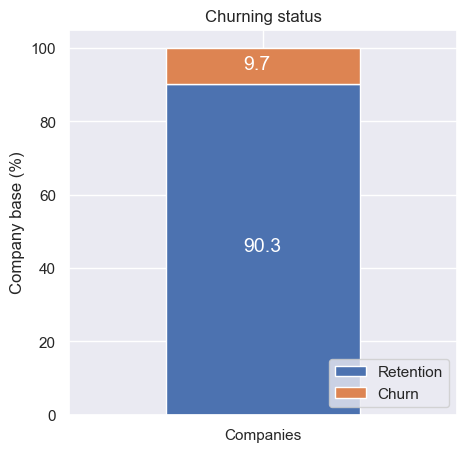

```python
churn = client_df[['id', 'churn']]
churn.columns = ['Companies', 'churn']
churn_total = churn.groupby(churn['churn']).count()
churn_percentage = churn_total / churn_total.sum() * 100
plot_stacked_bars(churn_percentage.transpose(), "Churning status", (5, 5), legend_="lower right")
```

```python
def plot_distribution(dataframe, column, ax, bins_=50):
    """
    Plot variable distirbution in a stacked histogram of churned or retained company
    """
    # Create a temporal dataframe with the data to be plot
    temp = pd.DataFrame({"Retention": dataframe[dataframe["churn"]==0][column],
    "Churn":dataframe[dataframe["churn"]==1][column]})
    # Plot the histogram
    temp[["Retention","Churn"]].plot(kind='hist', bins=bins_, ax=ax, stacked=True)
    # X-axis label
    ax.set_xlabel(column)
    # Change the x-axis to plain style
    ax.ticklabel_format(style='plain', axis='x')
```

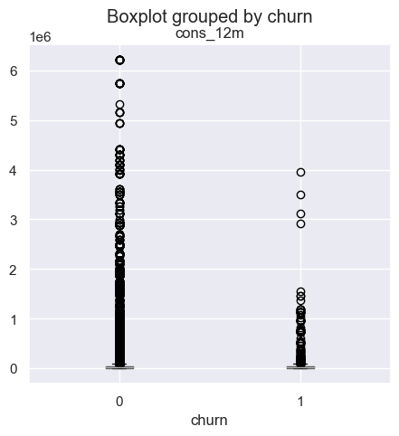

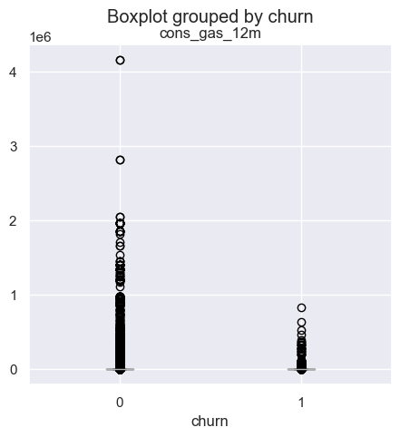

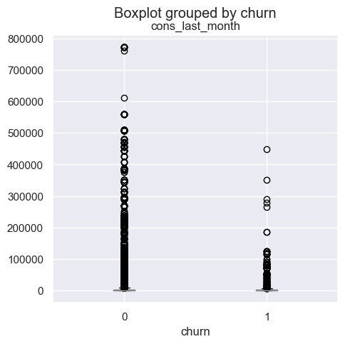

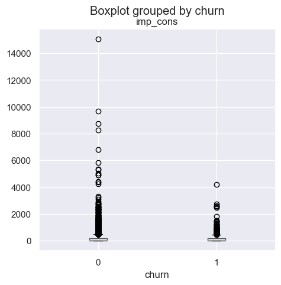

```python
consumption = client_df[["cons_12m", "cons_gas_12m", "cons_last_month", "imp_cons"]]

for col in consumption:
  client_df.boxplot(column=col, by="churn", figsize=(5,5))
  plt.title(col)
plt.show()
```

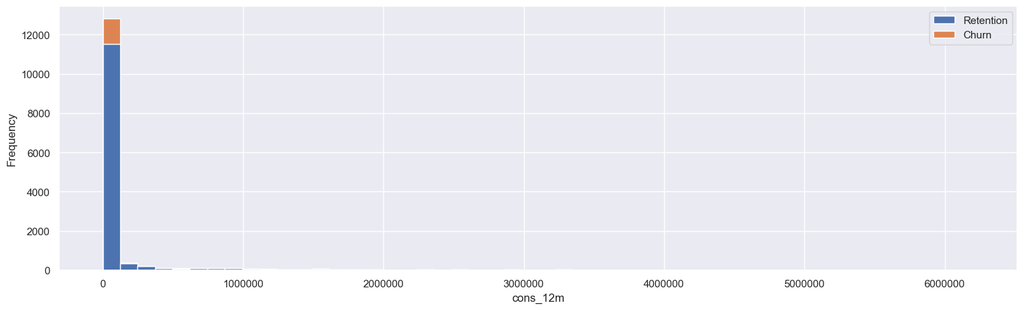

```python
consumption = client_df[['id', 'cons_12m', 'cons_gas_12m', 'cons_last_month', 'imp_cons', 'has_gas', 'churn']]

fig, axs = plt.subplots(nrows=1, figsize=(18, 5))

plot_distribution(consumption, 'cons_12m', axs)
```

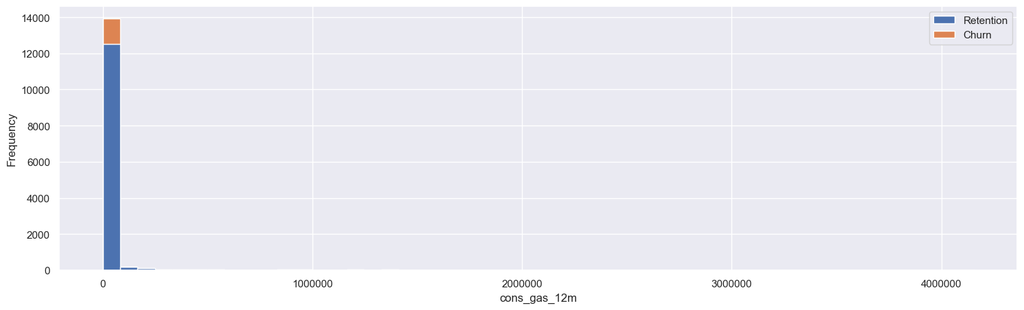

```python
fig, axs = plt.subplots(nrows=1, figsize=(18, 5))

plot_distribution(consumption, 'cons_gas_12m', axs)
```

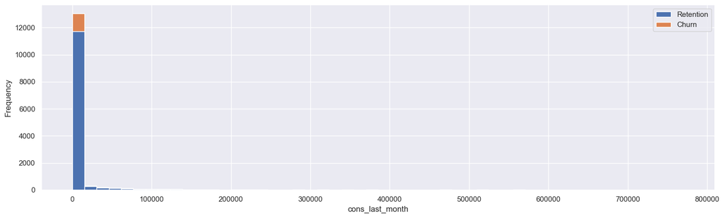

```python
fig, axs = plt.subplots(nrows=1, figsize=(18, 5))
plot_distribution(consumption, 'cons_last_month', axs)
```

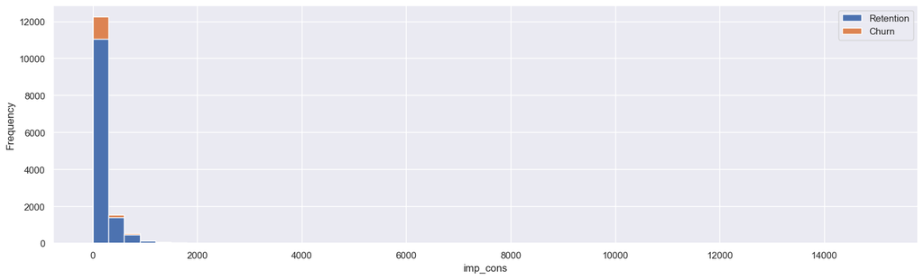

```python
fig, axs = plt.subplots(nrows=1, figsize=(18, 5))
plot_distribution(consumption,'imp_cons', axs)
```

Probability Distribution Plots for Consumption

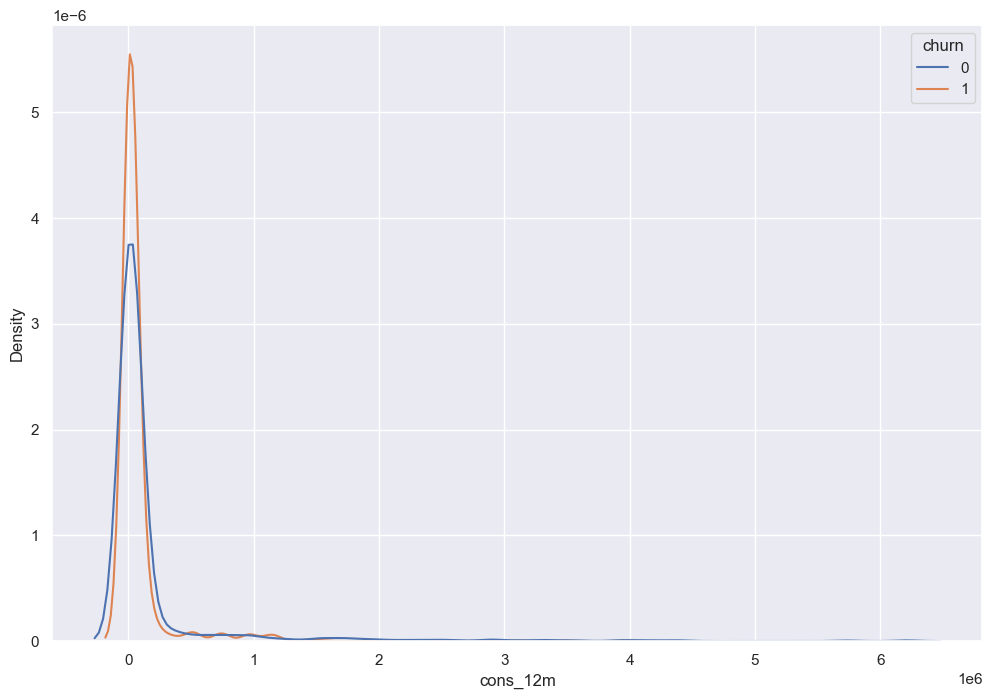

```python
plt.figure(figsize=(12, 8))
sns.kdeplot(data=client_df, x='cons_12m', hue = 'churn', common_norm = False)
```

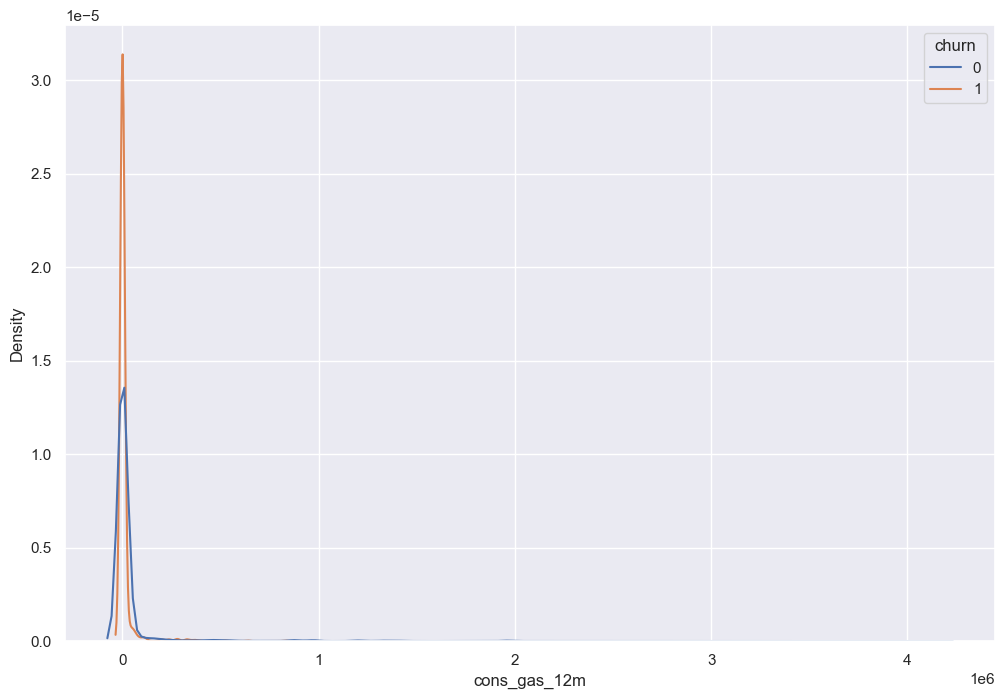

```python
plt.figure(figsize=(12, 8))
sns.kdeplot(data=client_df, x='cons_gas_12m', hue = 'churn', common_norm = False)
```

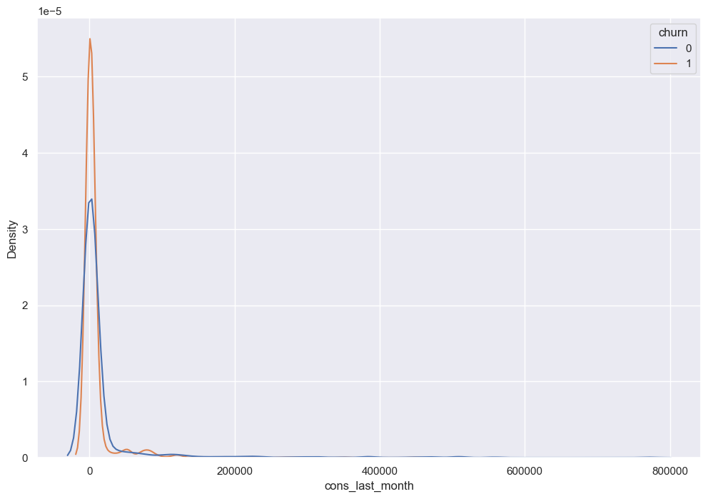

```python
plt.figure(figsize=(12, 8))
sns.kdeplot(data=client_df, x='cons_last_month', hue = 'churn', common_norm = False)
```

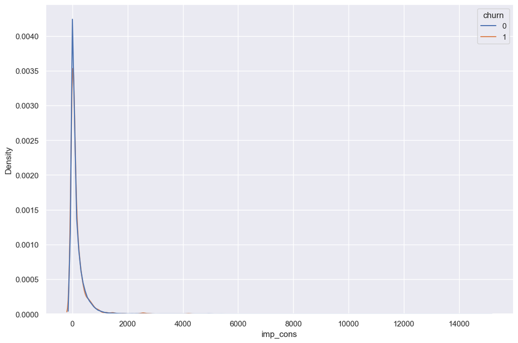

```python
plt.figure(figsize=(12, 8))
sns.kdeplot(data=client_df, x='imp_cons', hue = 'churn', common_norm = False)
```

Forecast

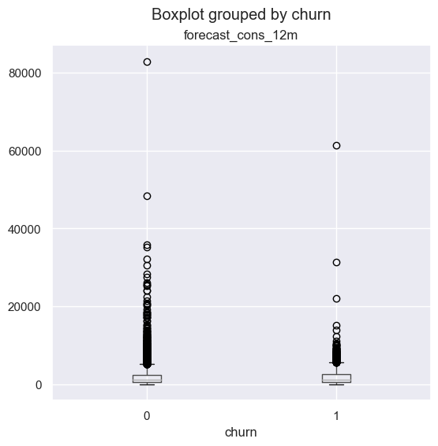

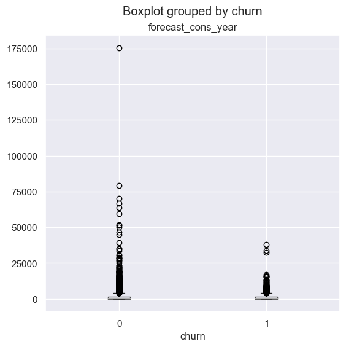

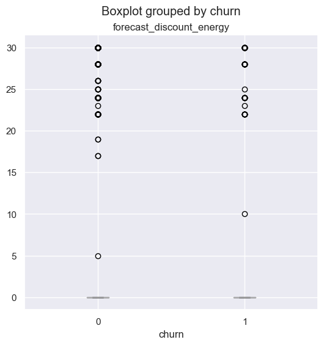

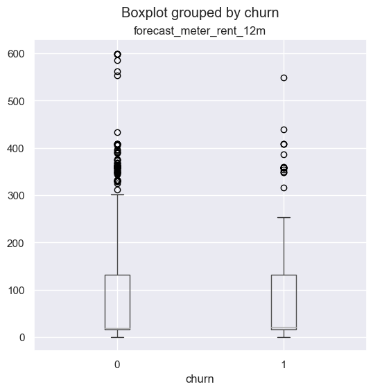

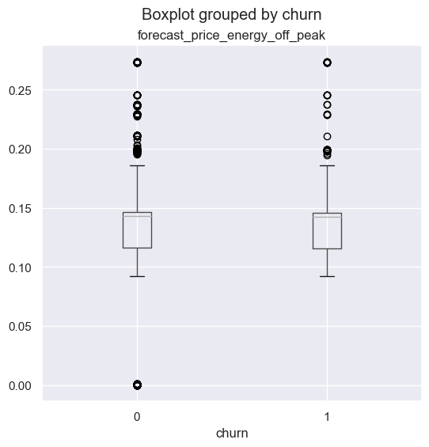

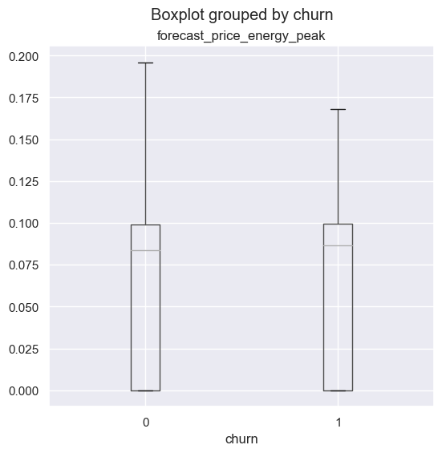

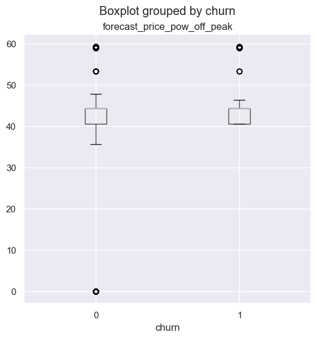

```python
forecast = client_df[["forecast_cons_12m", "forecast_cons_year","forecast_discount_energy","forecast_meter_rent_12m",
    "forecast_price_energy_off_peak","forecast_price_energy_peak", "forecast_price_pow_off_peak"]]


for col in forecast:
    client_df.boxplot(column=col, by='churn', figsize=(6,6))
    plt.title(col)
plt.show()
```

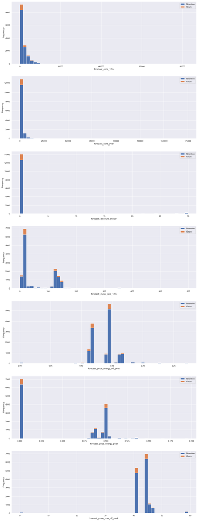

```python
fig, axs = plt.subplots(nrows=7, figsize=(18,50))

# Plot histogram
plot_distribution(client_df, "forecast_cons_12m", axs[0])
plot_distribution(client_df, "forecast_cons_year", axs[1])
plot_distribution(client_df, "forecast_discount_energy", axs[2])
plot_distribution(client_df, "forecast_meter_rent_12m", axs[3])
plot_distribution(client_df, "forecast_price_energy_off_peak", axs[4])
plot_distribution(client_df, "forecast_price_energy_peak", axs[5])
plot_distribution(client_df, "forecast_price_pow_off_peak", axs[6])
```

Price Data

```python
price_df
```

|  | id | price_date | price_off_peak_var | price_peak_var | price_mid_peak_var | price_off_peak_fix | price_peak_fix | price_mid_peak_fix |
| --- | --- | --- | --- | --- | --- | --- | --- | --- |
| 0 | 038af19179925da21a25619c5a24b745 | 2015-01-01 | 0.151367 | 0.000000 | 0.000000 | 44.266931 | 0.00000 | 0.000000 |
| 1 | 038af19179925da21a25619c5a24b745 | 2015-02-01 | 0.151367 | 0.000000 | 0.000000 | 44.266931 | 0.00000 | 0.000000 |
| 2 | 038af19179925da21a25619c5a24b745 | 2015-03-01 | 0.151367 | 0.000000 | 0.000000 | 44.266931 | 0.00000 | 0.000000 |
| 3 | 038af19179925da21a25619c5a24b745 | 2015-04-01 | 0.149626 | 0.000000 | 0.000000 | 44.266931 | 0.00000 | 0.000000 |
| 4 | 038af19179925da21a25619c5a24b745 | 2015-05-01 | 0.149626 | 0.000000 | 0.000000 | 44.266931 | 0.00000 | 0.000000 |
| ... | ... | ... | ... | ... | ... | ... | ... | ... |
| 192997 | 16f51cdc2baa19af0b940ee1b3dd17d5 | 2015-08-01 | 0.119916 | 0.102232 | 0.076257 | 40.728885 | 24.43733 | 16.291555 |
| 192998 | 16f51cdc2baa19af0b940ee1b3dd17d5 | 2015-09-01 | 0.119916 | 0.102232 | 0.076257 | 40.728885 | 24.43733 | 16.291555 |
| 192999 | 16f51cdc2baa19af0b940ee1b3dd17d5 | 2015-10-01 | 0.119916 | 0.102232 | 0.076257 | 40.728885 | 24.43733 | 16.291555 |
| 193000 | 16f51cdc2baa19af0b940ee1b3dd17d5 | 2015-11-01 | 0.119916 | 0.102232 | 0.076257 | 40.728885 | 24.43733 | 16.291555 |
| 193001 | 16f51cdc2baa19af0b940ee1b3dd17d5 | 2015-12-01 | 0.119916 | 0.102232 | 0.076257 | 40.728885 | 24.43733 | 16.291555 |

193002 rows × 8 columns

```python
min(price_df['price_date'])
```

```
'2015-01-01'
```

```python
max(price_df['price_date'])
```

```
'2015-12-01'
```

```python
client_df.columns
```

```
Index(['id', 'channel_sales', 'cons_12m', 'cons_gas_12m', 'cons_last_month',
       'date_activ', 'date_end', 'date_modif_prod', 'date_renewal',
       'forecast_cons_12m', 'forecast_cons_year', 'forecast_discount_energy',
       'forecast_meter_rent_12m', 'forecast_price_energy_off_peak',
       'forecast_price_energy_peak', 'forecast_price_pow_off_peak', 'has_gas',
       'imp_cons', 'margin_gross_pow_ele', 'margin_net_pow_ele', 'nb_prod_act',
       'net_margin', 'num_years_antig', 'origin_up', 'pow_max', 'churn'],
      dtype='object')
```

```python
date_cols = ['date_activ', 'date_end', 'date_modif_prod', 'date_renewal']
for i in date_cols:
    client_df[i] = pd.to_datetime(client_df[i])
```

```python
is_2015 = client_df['date_renewal'].dt.year == 2015
```

```python
is_2015.value_counts()
```

```
True     13297
False     1309
Name: date_renewal, dtype: int64
```

```python
client_df.head(3)
```

|  | id | channel_sales | cons_12m | cons_gas_12m | cons_last_month | date_activ | date_end | date_modif_prod | date_renewal | forecast_cons_12m | ... | has_gas | imp_cons | margin_gross_pow_ele | margin_net_pow_ele | nb_prod_act | net_margin | num_years_antig | origin_up | pow_max | churn |
| --- | --- | --- | --- | --- | --- | --- | --- | --- | --- | --- | --- | --- | --- | --- | --- | --- | --- | --- | --- | --- | --- |
| 0 | 24011ae4ebbe3035111d65fa7c15bc57 | foosdfpfkusacimwkcsosbicdxkicaua | 0 | 54946 | 0 | 2013-06-15 | 2016-06-15 | 2015-11-01 | 2015-06-23 | 0.00 | ... | t | 0.0 | 25.44 | 25.44 | 2 | 678.99 | 3 | lxidpiddsbxsbosboudacockeimpuepw | 43.648 | 1 |
| 1 | d29c2c54acc38ff3c0614d0a653813dd | MISSING | 4660 | 0 | 0 | 2009-08-21 | 2016-08-30 | 2009-08-21 | 2015-08-31 | 189.95 | ... | f | 0.0 | 16.38 | 16.38 | 1 | 18.89 | 6 | kamkkxfxxuwbdslkwifmmcsiusiuosws | 13.800 | 0 |
| 2 | 764c75f661154dac3a6c254cd082ea7d | foosdfpfkusacimwkcsosbicdxkicaua | 544 | 0 | 0 | 2010-04-16 | 2016-04-16 | 2010-04-16 | 2015-04-17 | 47.96 | ... | f | 0.0 | 28.60 | 28.60 | 1 | 6.60 | 6 | kamkkxfxxuwbdslkwifmmcsiusiuosws | 13.856 | 0 |

3 rows × 26 columns

```python
client_df['origin_up'].value_counts()
```

```
lxidpiddsbxsbosboudacockeimpuepw    7097
kamkkxfxxuwbdslkwifmmcsiusiuosws    4294
ldkssxwpmemidmecebumciepifcamkci    3148
MISSING                               64
usapbepcfoloekilkwsdiboslwaxobdp       2
ewxeelcelemmiwuafmddpobolfuxioce       1
Name: origin_up, dtype: int64
```

Price Dataframe

```python
price_df['id'].value_counts().value_counts()
```

```
count
12    15990
11       83
10       11
9         6
8         3
7         3
Name: count, dtype: int64
```

```python
price_df['price_date'].value_counts()
```

```
price_date
2015-08-01    16094
2015-12-01    16094
2015-07-01    16090
2015-11-01    16087
2015-06-01    16085
2015-10-01    16085
2015-02-01    16082
2015-09-01    16082
2015-05-01    16080
2015-04-01    16079
2015-03-01    16074
2015-01-01    16070
Name: count, dtype: int64
```

```python
price_df.columns
```

```
Index(['id', 'price_date', 'price_off_peak_var', 'price_peak_var',
       'price_mid_peak_var', 'price_off_peak_fix', 'price_peak_fix',
       'price_mid_peak_fix'],
      dtype='object')
```

```python
price_df['price_date'].value_counts()
```

```
2015-08-01    16094
2015-12-01    16094
2015-07-01    16090
2015-11-01    16087
2015-06-01    16085
2015-10-01    16085
2015-02-01    16082
2015-09-01    16082
2015-05-01    16080
2015-04-01    16079
2015-03-01    16074
2015-01-01    16070
Name: price_date, dtype: int64
```

```python
print(max(price_df['price_off_peak_var']))
print(max(price_df['price_mid_peak_var']))
print(max(price_df['price_peak_var']))
```

```
0.2807
0.114102
0.229788
```

```python
price_df['price_date'] = pd.to_datetime(price_df['price_date'])
```

```python
price_df.head(5)
```

|  | id | price_date | price_off_peak_var | price_peak_var | price_mid_peak_var | price_off_peak_fix | price_peak_fix | price_mid_peak_fix |
| --- | --- | --- | --- | --- | --- | --- | --- | --- |
| 0 | 038af19179925da21a25619c5a24b745 | 2015-01-01 | 0.151367 | 0.0 | 0.0 | 44.266931 | 0.0 | 0.0 |
| 1 | 038af19179925da21a25619c5a24b745 | 2015-02-01 | 0.151367 | 0.0 | 0.0 | 44.266931 | 0.0 | 0.0 |
| 2 | 038af19179925da21a25619c5a24b745 | 2015-03-01 | 0.151367 | 0.0 | 0.0 | 44.266931 | 0.0 | 0.0 |
| 3 | 038af19179925da21a25619c5a24b745 | 2015-04-01 | 0.149626 | 0.0 | 0.0 | 44.266931 | 0.0 | 0.0 |
| 4 | 038af19179925da21a25619c5a24b745 | 2015-05-01 | 0.149626 | 0.0 | 0.0 | 44.266931 | 0.0 | 0.0 |

```python
group_price_date = price_df.groupby(['price_date']).mean()
```

```python
group_price_date
```

| price_date | price_off_peak_var | price_peak_var | price_mid_peak_var | price_off_peak_fix | price_peak_fix | price_mid_peak_fix |
| --- | --- | --- | --- | --- | --- | --- |
| 2015-01-01 | 0.142568 | 0.054950 | 0.030333 | 43.226643 | 10.692921 | 6.455861 |
| 2015-02-01 | 0.142767 | 0.055053 | 0.030367 | 43.238161 | 10.673719 | 6.449016 |
| 2015-03-01 | 0.143104 | 0.055118 | 0.030396 | 43.254033 | 10.644489 | 6.430121 |
| 2015-04-01 | 0.143259 | 0.056035 | 0.030492 | 43.288439 | 10.647277 | 6.423156 |
| 2015-05-01 | 0.143534 | 0.055359 | 0.030393 | 43.315388 | 10.602453 | 6.390806 |
| 2015-06-01 | 0.143731 | 0.055255 | 0.029902 | 43.347320 | 10.415769 | 6.281304 |
| 2015-07-01 | 0.143683 | 0.055369 | 0.030636 | 43.345012 | 10.642236 | 6.421464 |
| 2015-08-01 | 0.137933 | 0.053605 | 0.030717 | 43.365366 | 10.661678 | 6.431518 |
| 2015-09-01 | 0.137933 | 0.053532 | 0.030606 | 43.351874 | 10.602979 | 6.391788 |
| 2015-10-01 | 0.137899 | 0.053713 | 0.030641 | 43.354226 | 10.605431 | 6.396084 |
| 2015-11-01 | 0.137909 | 0.053620 | 0.030737 | 43.422764 | 10.641489 | 6.421622 |
| 2015-12-01 | 0.138011 | 0.053957 | 0.030732 | 43.504177 | 10.644109 | 6.427104 |

```python
price_df['id'].value_counts()
```

```
038af19179925da21a25619c5a24b745    12
97589d95ec46ab31ef238d18a616403f    12
97adbcd721fae4874f7ee287ea84200d    12
d74b4544363be674855cf931b6b8af25    12
27276020e48d73f589788d4e37c51879    12
                                    ..
83cf18b07114e495ae8b7fb235e45ee2     8
3e459d61dc831e29f8a9a9a59f95efd2     8
c5dcd5c506e565aaabffa29bc1ec0a37     7
bf89f2d8c1b133a134fd93603cb4c947     7
15b36e47cf04bf151e3f4438d12672e5     7
Name: id, Length: 16096, dtype: int64
```

```python
client_df['id'].value_counts()
```

```
24011ae4ebbe3035111d65fa7c15bc57    1
2fae70276cd7a4874a2aefcd68d5a184    1
a7a9dac0ffc2ad56c66a1b08d53d0e51    1
6cfbce2099a4163ea4fe422fb28829ea    1
4289e929ecd35a0754e697feb24a091b    1
                                   ..
0b69432a3ceee7763bf86ffe30c6bc2d    1
6cabca88c760284183f51f84e4a27b1e    1
de92494d7140dc94be6a1ebafaf98056    1
a8e828bfad0869527e9acdd39a36cc91    1
563dde550fd624d7352f3de77c0cdfcd    1
Name: id, Length: 14606, dtype: int64
```

```python
price_id = set(price_df['id'].unique())
client_id = set(client_df['id'].unique())
if price_id == client_id:
    print("Every value unique and same")
else:
    print("Check the data using a different method")
print(len(price_id))
print(len(client_id))
```

```
Check the data using a different method
16096
14606
```

```python
price_id = set(price_df['id'].unique())
client_id = set(client_df['id'].unique())

remaining_values = price_id - client_id

if len(remaining_values) == 0:
    print("Every value is unique and the same.")
else:
    print("The following values are in price_id but not in client_id:")
    print(len(remaining_values))
    print(remaining_values)
```

[output not shown]

```python
16096-14606
```

```
1490
```

```python
group_id = price_df.groupby(['id']).mean().reset_index()
```

```python
group_id
```

|  | id | price_off_peak_var | price_peak_var | price_mid_peak_var | price_off_peak_fix | price_peak_fix | price_mid_peak_fix |
| --- | --- | --- | --- | --- | --- | --- | --- |
| 0 | 0002203ffbb812588b632b9e628cc38d | 0.124338 | 0.103794 | 0.073160 | 40.701732 | 24.421038 | 16.280694 |
| 1 | 0004351ebdd665e6ee664792efc4fd13 | 0.146426 | 0.000000 | 0.000000 | 44.385450 | 0.000000 | 0.000000 |
| 2 | 0010bcc39e42b3c2131ed2ce55246e3c | 0.181558 | 0.000000 | 0.000000 | 45.319710 | 0.000000 | 0.000000 |
| 3 | 0010ee3855fdea87602a5b7aba8e42de | 0.118757 | 0.098292 | 0.069032 | 40.647427 | 24.388455 | 16.258971 |
| 4 | 00114d74e963e47177db89bc70108537 | 0.147926 | 0.000000 | 0.000000 | 44.266930 | 0.000000 | 0.000000 |
| ... | ... | ... | ... | ... | ... | ... | ... |
| 16091 | ffef185810e44254c3a4c6395e6b4d8a | 0.138863 | 0.115125 | 0.080780 | 40.896427 | 24.637456 | 16.507972 |
| 16092 | fffac626da707b1b5ab11e8431a4d0a2 | 0.147137 | 0.000000 | 0.000000 | 44.311375 | 0.000000 | 0.000000 |
| 16093 | fffc0cacd305dd51f316424bbb08d1bd | 0.153879 | 0.129497 | 0.094842 | 41.160171 | 24.895768 | 16.763569 |
| 16094 | fffe4f5646aa39c7f97f95ae2679ce64 | 0.123858 | 0.103499 | 0.073735 | 40.606699 | 24.364017 | 16.242678 |
| 16095 | ffff7fa066f1fb305ae285bb03bf325a | 0.125360 | 0.104895 | 0.075635 | 40.647427 | 24.388455 | 16.258971 |

16096 rows × 7 columns

```python
group_id_price_date
```

|  | id | price_date | price_off_peak_var | price_peak_var | price_mid_peak_var | price_off_peak_fix | price_peak_fix | price_mid_peak_fix |
| --- | --- | --- | --- | --- | --- | --- | --- | --- |
| 0 | 0002203ffbb812588b632b9e628cc38d | 2015-01-01 | 0.126098 | 0.103975 | 0.070232 | 40.565969 | 24.339581 | 16.226389 |
| 1 | 0002203ffbb812588b632b9e628cc38d | 2015-02-01 | 0.126098 | 0.103975 | 0.070232 | 40.565969 | 24.339581 | 16.226389 |
| 2 | 0002203ffbb812588b632b9e628cc38d | 2015-03-01 | 0.128067 | 0.105842 | 0.073773 | 40.728885 | 24.437330 | 16.291555 |
| 3 | 0002203ffbb812588b632b9e628cc38d | 2015-04-01 | 0.128067 | 0.105842 | 0.073773 | 40.728885 | 24.437330 | 16.291555 |
| 4 | 0002203ffbb812588b632b9e628cc38d | 2015-05-01 | 0.128067 | 0.105842 | 0.073773 | 40.728885 | 24.437330 | 16.291555 |
| ... | ... | ... | ... | ... | ... | ... | ... | ... |
| 192997 | ffff7fa066f1fb305ae285bb03bf325a | 2015-08-01 | 0.119916 | 0.102232 | 0.076257 | 40.728885 | 24.437330 | 16.291555 |
| 192998 | ffff7fa066f1fb305ae285bb03bf325a | 2015-09-01 | 0.119916 | 0.102232 | 0.076257 | 40.728885 | 24.437330 | 16.291555 |
| 192999 | ffff7fa066f1fb305ae285bb03bf325a | 2015-10-01 | 0.119916 | 0.102232 | 0.076257 | 40.728885 | 24.437330 | 16.291555 |
| 193000 | ffff7fa066f1fb305ae285bb03bf325a | 2015-11-01 | 0.119916 | 0.102232 | 0.076257 | 40.728885 | 24.437330 | 16.291555 |
| 193001 | ffff7fa066f1fb305ae285bb03bf325a | 2015-12-01 | 0.119916 | 0.102232 | 0.076257 | 40.728885 | 24.437330 | 16.291555 |

193002 rows × 8 columns

```python
client_df['date_end'].value_counts()
```

```
2016-02-01    145
2016-08-01    125
2016-09-01    117
2016-10-05    115
2016-12-31    104
             ...
2017-01-29      1
2017-06-01      1
2017-01-28      1
2017-06-13      1
2017-06-11      1
Name: date_end, Length: 368, dtype: int64
```

```python
client_group_id_date_end = client_df.groupby(['id']).mean()
```

```python
client_group_id = client_group_id.reset_index()
```

```python
client_group_id
```

|  | id | cons_12m | cons_gas_12m | cons_last_month | forecast_cons_12m | forecast_cons_year | forecast_discount_energy | forecast_meter_rent_12m | forecast_price_energy_off_peak | forecast_price_energy_peak | forecast_price_pow_off_peak | imp_cons | margin_gross_pow_ele | margin_net_pow_ele | nb_prod_act | net_margin | num_years_antig | pow_max | churn |
| --- | --- | --- | --- | --- | --- | --- | --- | --- | --- | --- | --- | --- | --- | --- | --- | --- | --- | --- | --- |
| 0 | 0002203ffbb812588b632b9e628cc38d | 22034.0 | 0.0 | 3084.0 | 729.06 | 425.0 | 0.0 | 138.95 | 0.116900 | 0.100015 | 40.606701 | 40.78 | 43.08 | 43.08 | 1.0 | 81.42 | 6.0 | 17.250 | 0.0 |
| 1 | 0004351ebdd665e6ee664792efc4fd13 | 4060.0 | 0.0 | 0.0 | 597.77 | 0.0 | 0.0 | 6.84 | 0.142065 | 0.000000 | 44.311378 | 0.00 | 24.42 | 24.42 | 1.0 | 61.58 | 6.0 | 13.200 | 0.0 |
| 2 | 0010bcc39e42b3c2131ed2ce55246e3c | 7440.0 | 0.0 | 1062.0 | 1311.16 | 1062.0 | 30.0 | 18.37 | 0.199230 | 0.000000 | 45.806878 | 213.76 | 38.58 | 38.58 | 2.0 | 81.61 | 3.0 | 13.856 | 0.0 |
| 3 | 00114d74e963e47177db89bc70108537 | 11272.0 | 0.0 | 0.0 | 1671.41 | 0.0 | 0.0 | 18.27 | 0.144149 | 0.000000 | 44.311378 | 0.00 | 29.76 | 29.76 | 1.0 | 157.99 | 6.0 | 13.200 | 0.0 |
| 4 | 0013f326a839a2f6ad87a1859952d227 | 267414.0 | 0.0 | 19394.0 | 3077.34 | 1760.0 | 0.0 | 144.86 | 0.118636 | 0.101750 | 40.606701 | 195.20 | 30.00 | 30.00 | 1.0 | 341.58 | 3.0 | 20.000 | 0.0 |
| ... | ... | ... | ... | ... | ... | ... | ... | ... | ... | ... | ... | ... | ... | ... | ... | ... | ... | ... | ... |
| 14601 | ffebf6a979dd0b17a41076df1057e733 | 117182.0 | 0.0 | 12674.0 | 7235.32 | 6340.0 | 0.0 | 140.94 | 0.112922 | 0.097810 | 40.606701 | 593.30 | 13.02 | 13.02 | 1.0 | 742.37 | 11.0 | 34.640 | 0.0 |
| 14602 | fffac626da707b1b5ab11e8431a4d0a2 | 131409.0 | 0.0 | 4405.0 | 2310.41 | 0.0 | 0.0 | 18.32 | 0.143166 | 0.000000 | 44.311378 | 0.00 | 12.98 | 12.98 | 1.0 | 191.60 | 5.0 | 15.000 | 0.0 |
| 14603 | fffc0cacd305dd51f316424bbb08d1bd | 40274.0 | 2055098.0 | 6247.0 | 3430.56 | 4980.0 | 24.0 | 144.06 | 0.148299 | 0.125137 | 41.105201 | 599.08 | 45.36 | 45.36 | 2.0 | 351.39 | 3.0 | 16.500 | 0.0 |
| 14604 | fffe4f5646aa39c7f97f95ae2679ce64 | 32066.0 | 2916.0 | 4879.0 | 3313.13 | 4879.0 | 0.0 | 130.31 | 0.115174 | 0.098837 | 40.606701 | 487.59 | 19.68 | 19.68 | 3.0 | 361.40 | 4.0 | 31.500 | 0.0 |
| 14605 | ffff7fa066f1fb305ae285bb03bf325a | 50806.0 | 0.0 | 5491.0 | 1038.70 | 1057.0 | 0.0 | 131.02 | 0.116910 | 0.100572 | 40.606701 | 103.02 | 23.72 | 23.72 | 1.0 | 132.20 | 4.0 | 19.000 | 0.0 |

14606 rows × 19 columns

```python
client_df.iloc[4]
```

```
id                                149d57cf92fc41cf94415803a877cb4b
channel_sales                                              MISSING
cons_12m                                                      4425
cons_gas_12m                                                     0
cons_last_month                                                526
date_activ                                     2010-01-13 00:00:00
date_end                                       2016-03-07 00:00:00
date_modif_prod                                2010-01-13 00:00:00
date_renewal                                   2015-03-09 00:00:00
forecast_cons_12m                                           445.75
forecast_cons_year                                             526
forecast_discount_energy                                       0.0
forecast_meter_rent_12m                                     131.73
forecast_price_energy_off_peak                              0.1169
forecast_price_energy_peak                                0.100015
forecast_price_pow_off_peak                              40.606701
has_gas                                                          f
imp_cons                                                     52.32
margin_gross_pow_ele                                         44.91
margin_net_pow_ele                                           44.91
nb_prod_act                                                      1
net_margin                                                   47.98
num_years_antig                                                  6
origin_up                         kamkkxfxxuwbdslkwifmmcsiusiuosws
pow_max                                                       19.8
churn                                                            0
Name: 4, dtype: object
```

```python
is_smaller = client_df['date_renewal'] < client_df['date_end']

all_smaller = is_smaller.all()
```

```python
all_smaller
```

```
True
```

```python
client_df.head()
```

|  | id | channel_sales | cons_12m | cons_gas_12m | cons_last_month | date_activ | date_end | date_modif_prod | date_renewal | forecast_cons_12m | ... | has_gas | imp_cons | margin_gross_pow_ele | margin_net_pow_ele | nb_prod_act | net_margin | num_years_antig | origin_up | pow_max | churn |
| --- | --- | --- | --- | --- | --- | --- | --- | --- | --- | --- | --- | --- | --- | --- | --- | --- | --- | --- | --- | --- | --- |
| 0 | 24011ae4ebbe3035111d65fa7c15bc57 | foosdfpfkusacimwkcsosbicdxkicaua | 0 | 54946 | 0 | 2013-06-15 | 2016-06-15 | 2015-11-01 | 2015-06-23 | 0.00 | ... | t | 0.00 | 25.44 | 25.44 | 2 | 678.99 | 3 | lxidpiddsbxsbosboudacockeimpuepw | 43.648 | 1 |
| 1 | d29c2c54acc38ff3c0614d0a653813dd | MISSING | 4660 | 0 | 0 | 2009-08-21 | 2016-08-30 | 2009-08-21 | 2015-08-31 | 189.95 | ... | f | 0.00 | 16.38 | 16.38 | 1 | 18.89 | 6 | kamkkxfxxuwbdslkwifmmcsiusiuosws | 13.800 | 0 |
| 2 | 764c75f661154dac3a6c254cd082ea7d | foosdfpfkusacimwkcsosbicdxkicaua | 544 | 0 | 0 | 2010-04-16 | 2016-04-16 | 2010-04-16 | 2015-04-17 | 47.96 | ... | f | 0.00 | 28.60 | 28.60 | 1 | 6.60 | 6 | kamkkxfxxuwbdslkwifmmcsiusiuosws | 13.856 | 0 |
| 3 | bba03439a292a1e166f80264c16191cb | lmkebamcaaclubfxadlmueccxoimlema | 1584 | 0 | 0 | 2010-03-30 | 2016-03-30 | 2010-03-30 | 2015-03-31 | 240.04 | ... | f | 0.00 | 30.22 | 30.22 | 1 | 25.46 | 6 | kamkkxfxxuwbdslkwifmmcsiusiuosws | 13.200 | 0 |
| 4 | 149d57cf92fc41cf94415803a877cb4b | MISSING | 4425 | 0 | 526 | 2010-01-13 | 2016-03-07 | 2010-01-13 | 2015-03-09 | 445.75 | ... | f | 52.32 | 44.91 | 44.91 | 1 | 47.98 | 6 | kamkkxfxxuwbdslkwifmmcsiusiuosws | 19.800 | 0 |

5 rows × 26 columns

```python
client_group_id.head()
```

|  | id | cons_12m | cons_gas_12m | cons_last_month | forecast_cons_12m | forecast_cons_year | forecast_discount_energy | forecast_meter_rent_12m | forecast_price_energy_off_peak | forecast_price_energy_peak | forecast_price_pow_off_peak | imp_cons | margin_gross_pow_ele | margin_net_pow_ele | nb_prod_act | net_margin | num_years_antig | pow_max | churn |
| --- | --- | --- | --- | --- | --- | --- | --- | --- | --- | --- | --- | --- | --- | --- | --- | --- | --- | --- | --- |
| 0 | 0002203ffbb812588b632b9e628cc38d | 22034.0 | 0.0 | 3084.0 | 729.06 | 425.0 | 0.0 | 138.95 | 0.116900 | 0.100015 | 40.606701 | 40.78 | 43.08 | 43.08 | 1.0 | 81.42 | 6.0 | 17.250 | 0.0 |
| 1 | 0004351ebdd665e6ee664792efc4fd13 | 4060.0 | 0.0 | 0.0 | 597.77 | 0.0 | 0.0 | 6.84 | 0.142065 | 0.000000 | 44.311378 | 0.00 | 24.42 | 24.42 | 1.0 | 61.58 | 6.0 | 13.200 | 0.0 |
| 2 | 0010bcc39e42b3c2131ed2ce55246e3c | 7440.0 | 0.0 | 1062.0 | 1311.16 | 1062.0 | 30.0 | 18.37 | 0.199230 | 0.000000 | 45.806878 | 213.76 | 38.58 | 38.58 | 2.0 | 81.61 | 3.0 | 13.856 | 0.0 |
| 3 | 00114d74e963e47177db89bc70108537 | 11272.0 | 0.0 | 0.0 | 1671.41 | 0.0 | 0.0 | 18.27 | 0.144149 | 0.000000 | 44.311378 | 0.00 | 29.76 | 29.76 | 1.0 | 157.99 | 6.0 | 13.200 | 0.0 |
| 4 | 0013f326a839a2f6ad87a1859952d227 | 267414.0 | 0.0 | 19394.0 | 3077.34 | 1760.0 | 0.0 | 144.86 | 0.118636 | 0.101750 | 40.606701 | 195.20 | 30.00 | 30.00 | 1.0 | 341.58 | 3.0 | 20.000 | 0.0 |

```python
group_id
```

|  | id | price_off_peak_var | price_peak_var | price_mid_peak_var | price_off_peak_fix | price_peak_fix | price_mid_peak_fix |
| --- | --- | --- | --- | --- | --- | --- | --- |
| 0 | 0002203ffbb812588b632b9e628cc38d | 0.124338 | 0.103794 | 0.073160 | 40.701732 | 24.421038 | 16.280694 |
| 1 | 0004351ebdd665e6ee664792efc4fd13 | 0.146426 | 0.000000 | 0.000000 | 44.385450 | 0.000000 | 0.000000 |
| 2 | 0010bcc39e42b3c2131ed2ce55246e3c | 0.181558 | 0.000000 | 0.000000 | 45.319710 | 0.000000 | 0.000000 |
| 3 | 0010ee3855fdea87602a5b7aba8e42de | 0.118757 | 0.098292 | 0.069032 | 40.647427 | 24.388455 | 16.258971 |
| 4 | 00114d74e963e47177db89bc70108537 | 0.147926 | 0.000000 | 0.000000 | 44.266930 | 0.000000 | 0.000000 |
| ... | ... | ... | ... | ... | ... | ... | ... |
| 16091 | ffef185810e44254c3a4c6395e6b4d8a | 0.138863 | 0.115125 | 0.080780 | 40.896427 | 24.637456 | 16.507972 |
| 16092 | fffac626da707b1b5ab11e8431a4d0a2 | 0.147137 | 0.000000 | 0.000000 | 44.311375 | 0.000000 | 0.000000 |
| 16093 | fffc0cacd305dd51f316424bbb08d1bd | 0.153879 | 0.129497 | 0.094842 | 41.160171 | 24.895768 | 16.763569 |
| 16094 | fffe4f5646aa39c7f97f95ae2679ce64 | 0.123858 | 0.103499 | 0.073735 | 40.606699 | 24.364017 | 16.242678 |
| 16095 | ffff7fa066f1fb305ae285bb03bf325a | 0.125360 | 0.104895 | 0.075635 | 40.647427 | 24.388455 | 16.258971 |

16096 rows × 7 columns

```python
client_price_merge = pd.merge(group_id,client_df[['id','churn']],on='id')
```

```python
client_price_merge['churn'].value_counts()
```

```
0    13187
1     1419
Name: churn, dtype: int64
```

```python
merged_df = client_df.merge(group_id, on='id', how='left')
```

```python
merged_df= merged_df.reset_index()
```

```python
merged_df
```

|  | index | id | channel_sales | cons_12m | cons_gas_12m | cons_last_month | date_activ | date_end | date_modif_prod | date_renewal | ... | num_years_antig | origin_up | pow_max | churn | price_off_peak_var | price_peak_var | price_mid_peak_var | price_off_peak_fix | price_peak_fix | price_mid_peak_fix |
| --- | --- | --- | --- | --- | --- | --- | --- | --- | --- | --- | --- | --- | --- | --- | --- | --- | --- | --- | --- | --- | --- |
| 0 | 0 | 24011ae4ebbe3035111d65fa7c15bc57 | foosdfpfkusacimwkcsosbicdxkicaua | 0 | 54946 | 0 | 2013-06-15 | 2016-06-15 | 2015-11-01 | 2015-06-23 | ... | 3 | lxidpiddsbxsbosboudacockeimpuepw | 43.648 | 1 | 0.124787 | 0.100749 | 0.066530 | 40.942265 | 22.352010 | 14.901340 |
| 1 | 1 | d29c2c54acc38ff3c0614d0a653813dd | MISSING | 4660 | 0 | 0 | 2009-08-21 | 2016-08-30 | 2009-08-21 | 2015-08-31 | ... | 6 | kamkkxfxxuwbdslkwifmmcsiusiuosws | 13.800 | 0 | 0.149609 | 0.007124 | 0.000000 | 44.311375 | 0.000000 | 0.000000 |
| 2 | 2 | 764c75f661154dac3a6c254cd082ea7d | foosdfpfkusacimwkcsosbicdxkicaua | 544 | 0 | 0 | 2010-04-16 | 2016-04-16 | 2010-04-16 | 2015-04-17 | ... | 6 | kamkkxfxxuwbdslkwifmmcsiusiuosws | 13.856 | 0 | 0.170512 | 0.088421 | 0.000000 | 44.385450 | 0.000000 | 0.000000 |
| 3 | 3 | bba03439a292a1e166f80264c16191cb | lmkebamcaaclubfxadlmueccxoimlema | 1584 | 0 | 0 | 2010-03-30 | 2016-03-30 | 2010-03-30 | 2015-03-31 | ... | 6 | kamkkxfxxuwbdslkwifmmcsiusiuosws | 13.200 | 0 | 0.151210 | 0.000000 | 0.000000 | 44.400265 | 0.000000 | 0.000000 |
| 4 | 4 | 149d57cf92fc41cf94415803a877cb4b | MISSING | 4425 | 0 | 526 | 2010-01-13 | 2016-03-07 | 2010-01-13 | 2015-03-09 | ... | 6 | kamkkxfxxuwbdslkwifmmcsiusiuosws | 19.800 | 0 | 0.124174 | 0.103638 | 0.072865 | 40.688156 | 24.412893 | 16.275263 |
| ... | ... | ... | ... | ... | ... | ... | ... | ... | ... | ... | ... | ... | ... | ... | ... | ... | ... | ... | ... | ... | ... |
| 14601 | 14601 | 18463073fb097fc0ac5d3e040f356987 | foosdfpfkusacimwkcsosbicdxkicaua | 32270 | 47940 | 0 | 2012-05-24 | 2016-05-08 | 2015-05-08 | 2014-05-26 | ... | 4 | lxidpiddsbxsbosboudacockeimpuepw | 15.000 | 0 | 0.144124 | 0.000000 | 0.000000 | 44.370635 | 0.000000 | 0.000000 |
| 14602 | 14602 | d0a6f71671571ed83b2645d23af6de00 | foosdfpfkusacimwkcsosbicdxkicaua | 7223 | 0 | 181 | 2012-08-27 | 2016-08-27 | 2012-08-27 | 2015-08-28 | ... | 3 | lxidpiddsbxsbosboudacockeimpuepw | 6.000 | 1 | 0.106799 | 0.095406 | 0.070817 | 59.015674 | 36.393379 | 8.345418 |
| 14603 | 14603 | 10e6828ddd62cbcf687cb74928c4c2d2 | foosdfpfkusacimwkcsosbicdxkicaua | 1844 | 0 | 179 | 2012-02-08 | 2016-02-07 | 2012-02-08 | 2015-02-09 | ... | 4 | lxidpiddsbxsbosboudacockeimpuepw | 15.935 | 1 | 0.124338 | 0.103794 | 0.073160 | 40.701732 | 24.421038 | 16.280694 |
| 14604 | 14604 | 1cf20fd6206d7678d5bcafd28c53b4db | foosdfpfkusacimwkcsosbicdxkicaua | 131 | 0 | 0 | 2012-08-30 | 2016-08-30 | 2012-08-30 | 2015-08-31 | ... | 3 | lxidpiddsbxsbosboudacockeimpuepw | 11.000 | 0 | 0.149609 | 0.007124 | 0.000000 | 44.311375 | 0.000000 | 0.000000 |
| 14605 | 14605 | 563dde550fd624d7352f3de77c0cdfcd | MISSING | 8730 | 0 | 0 | 2009-12-18 | 2016-12-17 | 2009-12-18 | 2015-12-21 | ... | 6 | ldkssxwpmemidmecebumciepifcamkci | 10.392 | 0 | 0.168662 | 0.087344 | 0.000000 | 44.266930 | 0.000000 | 0.000000 |

14606 rows × 33 columns

```python
main_df = merged_df
```

```python
main_df.columns
```

```
Index(['index', 'id', 'channel_sales', 'cons_12m', 'cons_gas_12m',
       'cons_last_month', 'date_activ', 'date_end', 'date_modif_prod',
       'date_renewal', 'forecast_cons_12m', 'forecast_cons_year',
       'forecast_discount_energy', 'forecast_meter_rent_12m',
       'forecast_price_energy_off_peak', 'forecast_price_energy_peak',
       'forecast_price_pow_off_peak', 'has_gas', 'imp_cons',
       'margin_gross_pow_ele', 'margin_net_pow_ele', 'nb_prod_act',
       'net_margin', 'num_years_antig', 'origin_up', 'pow_max', 'churn',
       'price_off_peak_var', 'price_peak_var', 'price_mid_peak_var',
       'price_off_peak_fix', 'price_peak_fix', 'price_mid_peak_fix'],
      dtype='object')
```

```python
main_df_cor = main_df[['churn',
       'price_off_peak_var', 'price_peak_var', 'price_mid_peak_var',
       'price_off_peak_fix', 'price_peak_fix', 'price_mid_peak_fix']]
```

```python
main_df_cor
```

|  | churn | price_off_peak_var | price_peak_var | price_mid_peak_var | price_off_peak_fix | price_peak_fix | price_mid_peak_fix |
| --- | --- | --- | --- | --- | --- | --- | --- |
| 0 | 1 | 0.124787 | 0.100749 | 0.066530 | 40.942265 | 22.352010 | 14.901340 |
| 1 | 0 | 0.149609 | 0.007124 | 0.000000 | 44.311375 | 0.000000 | 0.000000 |
| 2 | 0 | 0.170512 | 0.088421 | 0.000000 | 44.385450 | 0.000000 | 0.000000 |
| 3 | 0 | 0.151210 | 0.000000 | 0.000000 | 44.400265 | 0.000000 | 0.000000 |
| 4 | 0 | 0.124174 | 0.103638 | 0.072865 | 40.688156 | 24.412893 | 16.275263 |
| ... | ... | ... | ... | ... | ... | ... | ... |
| 14601 | 0 | 0.144124 | 0.000000 | 0.000000 | 44.370635 | 0.000000 | 0.000000 |
| 14602 | 1 | 0.106799 | 0.095406 | 0.070817 | 59.015674 | 36.393379 | 8.345418 |
| 14603 | 1 | 0.124338 | 0.103794 | 0.073160 | 40.701732 | 24.421038 | 16.280694 |
| 14604 | 0 | 0.149609 | 0.007124 | 0.000000 | 44.311375 | 0.000000 | 0.000000 |
| 14605 | 0 | 0.168662 | 0.087344 | 0.000000 | 44.266930 | 0.000000 | 0.000000 |

14606 rows × 7 columns

## SUB TASK 2

```python
corr = main_df_cor.corr()
```

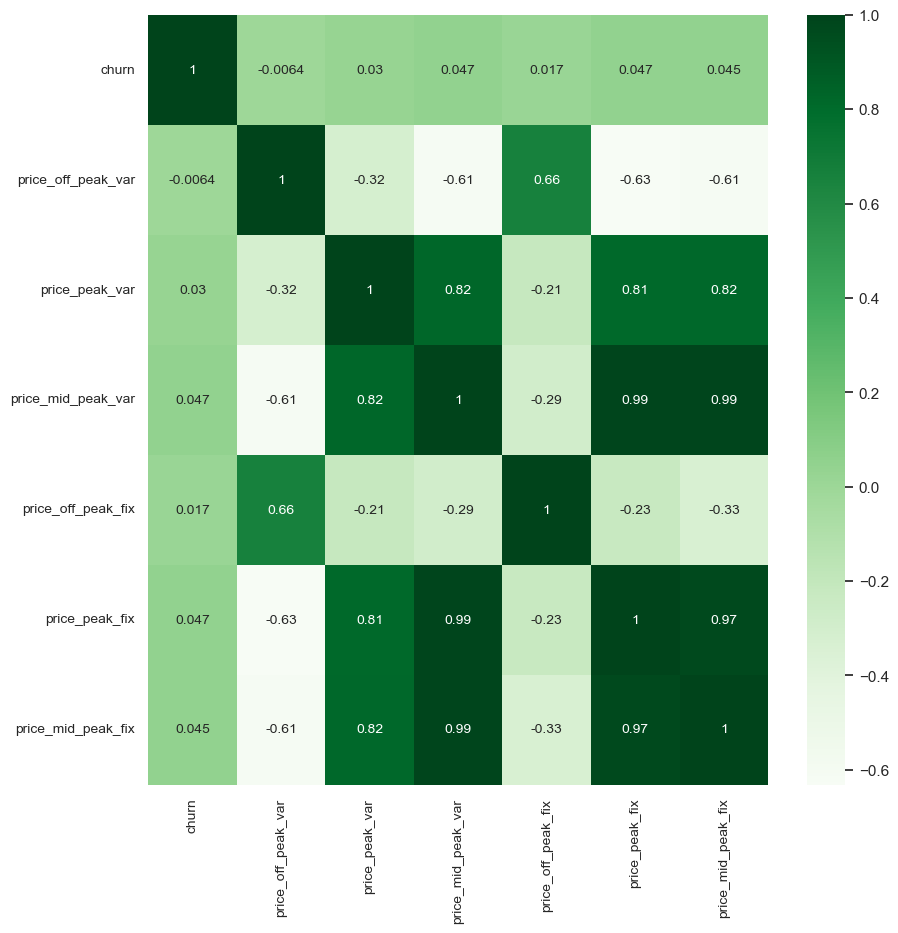

```python
plt.figure(figsize = (10,10))
sns.heatmap(corr, xticklabels=corr.columns.values, yticklabels=corr.columns.values, cmap='Greens',annot=True,annot_kws={'size':10})
plt.xticks(fontsize=10)
plt.yticks(fontsize=10)
plt.show()
```

Price sensitivity has no strong relation with the companies which have churned Churned companies has no strong dependency on price

```python
churn_0 = main_df_cor[main_df_cor['churn']==0].reset_index()
print(churn_0)
```

```
       index  churn  price_off_peak_var  price_peak_var  price_mid_peak_var  \
0          1      0            0.149609        0.007124            0.000000
1          2      0            0.170512        0.088421            0.000000
2          3      0            0.151210        0.000000            0.000000
3          4      0            0.124174        0.103638            0.072865
4          7      0            0.122816        0.102501            0.073536
...      ...    ...                 ...             ...                 ...
13182  14599      0            0.146555        0.000000            0.000000
13183  14600      0            0.127914        0.107370            0.076736
13184  14601      0            0.144124        0.000000            0.000000
13185  14604      0            0.149609        0.007124            0.000000
13186  14605      0            0.168662        0.087344            0.000000

       price_off_peak_fix  price_peak_fix  price_mid_peak_fix
0               44.311375        0.000000            0.000000
1               44.385450        0.000000            0.000000
2               44.400265        0.000000            0.000000
3               40.688156       24.412893           16.275263
4               40.674580       24.404747           16.269833
...                   ...             ...                 ...
13182           44.266930        0.000000            0.000000
13183           40.701732       24.421038           16.280694
13184           44.370635        0.000000            0.000000
13185           44.311375        0.000000            0.000000
13186           44.266930        0.000000            0.000000

[13187 rows x 8 columns]
```

```python
churn_1 = main_df_cor[main_df_cor['churn']==1].reset_index()
print(churn_1)
```

```
      index  churn  price_off_peak_var  price_peak_var  price_mid_peak_var  \
0         0      1            0.124787        0.100749            0.066530
1         5      1            0.168953        0.087632            0.000000
2         6      1            0.166061        0.084744            0.000000
3        25      1            0.124068        0.103734            0.073529
4        30      1            0.147478        0.000000            0.000000
...     ...    ...                 ...             ...                 ...
1414  14587      1            0.150704        0.000000            0.000000
1415  14588      1            0.150956        0.000000            0.000000
1416  14593      1            0.146767        0.000000            0.000000
1417  14602      1            0.106799        0.095406            0.070817
1418  14603      1            0.124338        0.103794            0.073160

      price_off_peak_fix  price_peak_fix  price_mid_peak_fix
0              40.942265       22.352010           14.901340
1              44.266930        0.000000            0.000000
2              44.266930        0.000000            0.000000
3              40.621214       24.389392           16.273483
4              44.341005        0.000000            0.000000
...                  ...             ...                 ...
1414           44.448412        0.000000            0.000000
1415           44.444710        0.000000            0.000000
1416           44.341005        0.000000            0.000000
1417           59.015674       36.393379            8.345418
1418           40.701732       24.421038           16.280694

[1419 rows x 8 columns]
```

```python
print(min(churn_1['price_off_peak_var']))
print(max(churn_1['price_off_peak_var']))
```

```
0.10313974999999999
0.2777375833333333
```

```python
print(min(churn_0['price_off_peak_var']))
print(max(churn_0['price_off_peak_var']))
```

```
0.0
0.27809816666666665
```

```python
print(min(churn_1['price_peak_var']))
print(max(churn_1['price_peak_var']))
```

```
0.0
0.167235
```

```python
print(min(churn_0['price_peak_var']))
print(max(churn_0['price_peak_var']))
```

```
0.0
0.19627516666666664
```

```python
print(min(churn_1['price_mid_peak_var']))
print(max(churn_1['price_mid_peak_var']))
```

```
0.0
0.09497166666666668
```

```python
print(min(churn_0['price_mid_peak_var']))
print(max(churn_0['price_mid_peak_var']))
```

```
0.0
0.10295149999999993
```

```python
print(min(churn_1['price_off_peak_fix']))
print(max(churn_1['price_off_peak_fix']))
```

```
33.818552
59.226745359999995
```

```python
print(min(churn_0['price_off_peak_fix']))
print(max(churn_0['price_off_peak_fix']))
```

```
0.0
59.28619036
```

```python
print(min(churn_1['price_peak_fix']))
print(max(churn_1['price_peak_fix']))
```

```
0.0
36.490689
```

```python
print(min(churn_0['price_peak_fix']))
print(max(churn_0['price_peak_fix']))
```

```
0.0
36.490689
```

```python
print(min(churn_1['price_mid_peak_fix']))
print(max(churn_1['price_mid_peak_fix']))
```

```
0.0
16.79155536
```

```python
print(min(churn_0['price_mid_peak_fix']))
print(max(churn_0['price_mid_peak_fix']))
```

```
0.0
16.818917420000002
```